# PSYCH 413 Final Exam

# **Submission Instructions**

## **This exam is due Wednesday April 23rd by 08:30 a.m.**

### For calculation-based questions:

- Include the R code used for your analysis.
- Ensure that all code cells are executed in order and display the required outputs.
- Keep your notebook clean and well-organized:
  - Use Markdown to label sections, explain steps, and guide the reader.
  - Suppress or remove unnecessary outputs to improve readability.
- Round final answers (not intermediate steps) to 4–5 decimal places, if applicable.
- Assume a significance level of $\alpha = 0.05$ unless otherwise specified.
- Unless a specific test/analysis is requested:
  - Choose the most appropriate version based on assumption checks.
  - If the assumptions of a classical test (e.g., t-test, ANOVA) are **not violated**, use it instead of a robust alternative.
- If a question requires trimming, use 20% trimming.
- Do not remove outliers unless explicitly instructed to do so.
- When checking assumptions, support your conclusions with plots and/or relevant statistics.

**Note:** Good coding style will be rewarded. Code that is disorganized, redundant, or poorly structured may result in lost marks.

### The following functions are NOT PERMITTED unless otherwise stated.

### `t.test()` `yuen()`, `trimse()`, `cor()` `cor.test()` `p.adjust()` `lm()`, `confint()`, `anova()`, `aov()` `chisq.test()`, `IQR()`, `mad()`

- Functions from other packages that perform equivalent calculations to these functions are also disallowed.
- If any of these functions are permitted, the question will state which ones.

Bigfoot—also known as Sasquatch (*Gigantopithecus canadensis*)—is a legendary creature said to inhabit remote forested regions of North America, particularly the Pacific Northwest. Descriptions typically portray Bigfoot as a large, ape-like being standing approx. 7 to 10 feet tall, covered in dark hair, and walking upright like a human.

Reports of Bigfoot sightings date back centuries, including oral traditions from Indigenous peoples. In modern times, Bigfoot has become a pop culture icon, inspiring documentaries, hoaxes, merchandise, and scientific curiosity. Despite thousands of reported encounters, no conclusive physical evidence has been found, and the existence of Bigfoot remains highly inconclusive.

Psychologists are studying how media exposure and paranormal belief affect perceptual sensitivity in a Bigfoot detection task. Participants are randomly assigned to one of three media conditions:

- **Documentary** (serious pro-Bigfoot content)
- **Mockumentary** (satirical Bigfoot content)
- **Control** (neutral nature footage)

Participants are also categorized into two **paranormal belief groups** (Low vs. High), based on scores from a standardized paranormal belief questionnaire.

After viewing their assigned media, each participant completes a **Bigfoot signal detection task**, in which they view 40 images: 20 contain a camouflaged Bigfoot, 20 do not. On each trial, participants indicate whether they see Bigfoot.

For each participant, a statistic called **d′ (d-prime)** is calculated using their hit rate (correctly identifying Bigfoot when present) and false alarm rate (incorrectly identifying Bigfoot when not present). Note that in some cases the computer presenting the images failed and a d′ score could not be calculated.

The data is found in **squatch.csv**.

# Question 1

Create a plot with 95% CIs and use it to establish whether there is an interaction present between belief and media type.

Assume that all classical statistical assumptions (e.g., normality, homogeneity of variance) are met.

Ensure that the plot has a professional appearance that you would be proud to put in an academic paper.

```r
library(tidyverse)
squatch <- read_csv("squatch.csv") |>
  drop_na(d) # remove NAs

plot_data <- squatch |>
  group_by(media, belief) |>
  summarise(
    n = length(d),
    m = mean(d),
    se = sd(d) / sqrt(n),
    df = n - 1,
    alpha = 0.05,
    t_crit = abs(qt(alpha / 2, df = df)),
    moe = t_crit * se
  )

plot_data # Displaying so you can compare against my values
```

```
## # A tibble: 6 × 9
## # Groups:   media [3]
##   media        belief     n     m      se    df alpha t_crit    moe
##   <chr>        <chr>  <int> <dbl>   <dbl> <dbl> <dbl>  <dbl>  <dbl>
## 1 Control      High      72 2.127 0.09481    71  0.05  1.994 0.1890
## 2 Control      Low       72 1.913 0.1011     71  0.05  1.994 0.2016
## 3 Documentary  High      72 2.794 0.1155     71  0.05  1.994 0.2303
## 4 Documentary  Low       72 2.029 0.09962    71  0.05  1.994 0.1986
## 5 Mockumentary High      72 1.572 0.1121     71  0.05  1.994 0.2236
## 6 Mockumentary Low       72 1.965 0.1202     71  0.05  1.994 0.2397
```

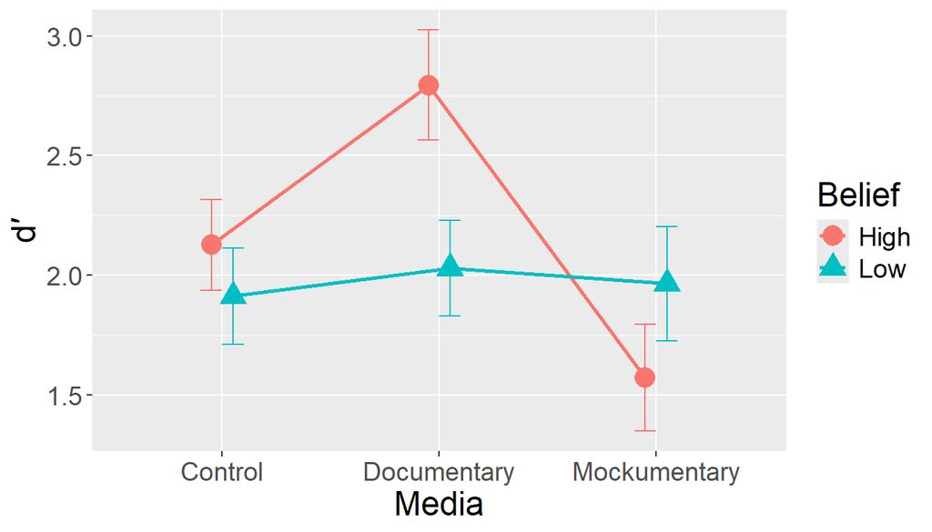

```r
ggplot(plot_data, aes(x = media, y = m,
                      group = belief,
                      colour = belief,
                      shape = belief)) +
  geom_point(size = 5, position = position_dodge(width = .2)) +
  geom_line(linewidth = 1, position = position_dodge(width = .2)) +
  geom_errorbar(aes(ymin = m - moe, ymax = m + moe),
                width = 0.2,
                position = position_dodge(width = .2)) +
  xlab("Media") + ylab("d′") +
  labs(colour = "Belief",
       shape = "Belief" ) +
  theme(
    axis.text = element_text(size = 14),
    axis.title = element_text(size = 18),
    legend.text = element_text(size = 14),
    legend.title = element_text(size = 18)
  )
```

The lines are not parallel, suggesting a interaction is present.

- Note: it is fine if you put *Belief* on the x-axis instead of *Media.*

# Question 2

Assume the data meets all the standard assumptions for a two-way independent ANOVA. Determine whether there is a significant main effect of media type, a main effect of belief level, and an interaction between the two on d′ scores. Describe the findings (including the effect size) in plain English.

Ensure that you report all the following:

- F stats
- Degrees of freedom
- p-value
- $\omega^2$

```r
grand_M <- mean(squatch$d)
N <- nrow(squatch)

# Total Sum of Squares: SST
SST <- sum((squatch$d - grand_M)^2)
```

```r
# Model Sum of Squares: SSM
sum_stat <- squatch |>
  group_by(media, belief) |>
  summarise(
    n = length(d),
    m = mean(d)
  )

SSM <- sum(sum_stat$n * (sum_stat$m - grand_M)^2)
```

```r
# Main Effect of media: SSA
sum_stat_A <- squatch |>
  group_by(media) |>
  summarise(
    n = length(d),
    m = mean(d)
  )

SSA <- sum(sum_stat_A$n * (sum_stat_A$m - grand_M)^2)

# Degrees of Freedom A
dfA <- nrow(sum_stat_A) - 1
```

```r
# Main Effect of belief: SSB
sum_stat_B <- squatch |>
  group_by(belief) |>
  summarise(
    n = length(d),
    m = mean(d)
  )

SSB <- sum(sum_stat_B$n * (sum_stat_B$m - grand_M)^2)

# Degrees of Freedom A
dfB <- nrow(sum_stat_B) - 1
```

```r
# Interaction between A and B (SSI)
SSI <- SSM - SSA - SSB

# Degrees of Freedom I
dfI <- dfA * dfB
```

```r
# Residual Sum of Squares (SSR)
SSR <- SST - SSM

# Degrees of Freedom R
A <- length(unique(squatch$media))
B <- length(unique(squatch$belief))
dfR <- (N - 1) - (A - 1) - (B - 1) - (A - 1) * (B - 1)
```

```r
# Mean Squares
MSA <- SSA / dfA
MSB <- SSB / dfB
MSI <- SSI / dfI
MSR <- SSR / dfR
```

```r
# F-Ratios
FA <- MSA / MSR
FB <- MSB / MSR
FI <- MSI / MSR
```

```r
# P-Values
pA <- pf(FA, df1 = dfA, df = dfR, lower.tail = FALSE)
pB <- pf(FB, df1 = dfB, df = dfR, lower.tail = FALSE)
pI <- pf(FI, df1 = dfI, df = dfR, lower.tail = FALSE)
```

```r
# Effect Sizes
omegasqA <- (SSA - (A - 1) * (MSR)) / (SST + MSR)
omegasqB <- (SSB - (B - 1) * (MSR)) / (SST + MSR)
omegasqI <- (SSI - (A - 1) * (B - 1) * (MSR)) / (SST + MSR)
```

```
## Main Effect of media:
##     F = 18.1437, df1 = 2, df2 = 426, p = 0, omega^2 = 0.069
##
## Main Effect of belief:
##     F = 4.937, df1 = 1, df2 = 426, p = 0.0268, omega^2 = 0.0079
##
## Interaction Effect:
##     F = 14.4696, df1 = 2, df2 = 426, p = 0, omega^2 = 0.0542
```

There was a moderately small but statistically significant main effect of media type, a very small but significant main effect of belief, and a small yet significant interaction between media type and belief on d′.

# Question 3

Use the `lm()` function to conduct a two-way ANOVA with planned contrasts to test the following specific comparisons and their interaction:

Media Exposure:

- Compare **Documentary + Mockumentary** vs **Control**
- Compare **Documentary** vs **Mockumentary**

Paranormal Belief:

- Compare **High Belief** vs **Low Belief**

In plain English, what is the primary insight gleaned from these contrasts?

FYI: The d′ score is a measure from signal detection theory that tells us how well someone can distinguish signal from noise—in this case, how well they can tell whether Bigfoot is really present in an image or not.

- A higher d′ means the person is more sensitive—they’re good at detecting Bigfoot when it’s there and not getting fooled when it’s not.
- A lower d′ means the person has poor sensitivity—they may miss real sightings or falsely think they saw Bigfoot when they didn’t.
- A d′ of 0 means the person is completely guessing—they can’t tell the difference between signal and noise at all.

```r
# Factor data
squatch$media <- factor(squatch$media)
squatch$belief <- factor(squatch$belief)

# Get level order
levels(squatch$media)
```

```
## [1] "Control"      "Documentary"  "Mockumentary"
```

```r
levels(squatch$belief)
```

```
## [1] "High" "Low"
```

```r
# Set contrasts
DM_vs_C <- c(-2, 1, 1)
D_vs_M <- c(0, 1, -1)
contrasts(squatch$media) <- cbind(DM_vs_C, D_vs_M)

High_vs_Low <- c(1, -1)
contrasts(squatch$belief) <- cbind(High_vs_Low)

# Anova model
squatch_mod <- lm(d ~ media + belief + media:belief, data = squatch)
summary(squatch_mod)
```

```
##
## Call:
## lm(formula = d ~ media + belief + media:belief, data = squatch)
##
## Residuals:
##      Min       1Q   Median       3Q      Max
## -2.51093 -0.63065 -0.00047  0.61440  2.82068
##
## Coefficients:
##                                 Estimate Std. Error t value Pr(>|t|)
## (Intercept)                     2.066784   0.043940  47.037  < 2e-16 ***
## mediaDM_vs_C                    0.023371   0.031070   0.752   0.4523
## mediaD_vs_M                     0.321639   0.053815   5.977 4.82e-09 ***
## beliefHigh_vs_Low               0.097633   0.043940   2.222   0.0268 *
## mediaDM_vs_C:beliefHigh_vs_Low -0.004634   0.031070  -0.149   0.8815
## mediaD_vs_M:beliefHigh_vs_Low   0.289387   0.053815   5.377 1.25e-07 ***
## ---
## Signif. codes:  0 '***' 0.001 '**' 0.01 '*' 0.05 '.' 0.1 ' ' 1
##
## Residual standard error: 0.9133 on 426 degrees of freedom
## Multiple R-squared:  0.1414, Adjusted R-squared:  0.1313
## F-statistic: 14.03 on 5 and 426 DF,  p-value: 1.03e-12
```

There is a significant difference in Bigfoot detection ability after watching the documentary compared to the mockumentary, but this is dependent on the person’s belief in the paranormal.

# Question 4

Based on the **squatch.csv** data, is there reason to think that a person’s paranormal belief (high vs low) is dependent on their sex? Use $\alpha = 0.01$.

Also report the following:

- Test Statistic
- Degrees of freedom
- p-value

```r
# Reload data to bring back removed rows
squatch <- read_csv("squatch.csv")

# Observed frequencies
obs_freq <- table(squatch$sex, squatch$belief)
obs_freq
```

```
##
##          High Low
##   Female  154 139
##   Male     68  83
```

```r
# Row totals
row_tot <- apply(obs_freq, MARGIN = 1, FUN = sum)

# Col Totals
col_total <- apply(obs_freq, MARGIN = 2, FUN = sum)

# Total Number of Observations
N <- sum(col_total)

# exp_freq Frequencies
exp_freq <- row_tot %*% t(col_total) / N
exp_freq
```

```
##       High   Low
## [1,] 146.5 146.5
## [2,]  75.5  75.5
```

```r
# Test stat
chisq <- sum((obs_freq - exp_freq)^2 / exp_freq)

#p-value
df <- (2 - 1) * (2 - 1)
p <- pchisq(chisq, df = df, lower.tail = FALSE)
```

```
## [1] "Chisq = 2.258, df = 1, p = 0.13293"
```

There is not sufficient evidence to think a person’s belief is dependent on their sex.

# Question 5

If you have a linear model of the form …

$\hat{y} = b_0 + b_1 x$

Calculate $R^2$ for this model given the following info.

- $N = 91$
- $s_{resid} = 0.437$
- $SST = 62.1$

```r
N <- 91
s_resid <- 0.437
SST <- 62.1

# Degrees of Freedom (N - 2)
df <- N - 1 - 1

# Sum of Squared Residuals
SSR <- (s_resid^2) * df

# R-squared
R_sq <- 1 - (SSR/SST)
R_sq
```

```
## [1] 0.7263085
```

Note: To solve this I am just rearranging the formula for residual standard error.

$s_{resid} = \sqrt{\frac{\sum (y - \hat{y})^2}{N-2}} = \sqrt{\frac{SSR}{N-2}}$

Remove the square-root…

$s_{resid}^2 = \frac{SSR}{N-2}$

Now we can solve for SSR …

$SSR = (s_{resid}^2)(N - 2) = 16.9962$

With $SSR$ and $SST$ known, we can calculate $R^2$…

$R^2 = 1 - \frac{SSR}{SST} = 0.7263$

# Question 6

A researcher tests a new treatment designed to reduce student laziness. Based on the results, they report a p-value of 0.044 and conclude that the treatment is effective.

In this context, what does the p-value actually tell us? Be precise in your explanation.

- It means that, if you **assume the null hypothesis is true**, there is a 4.4% chance of obtaining a result **as extreme** as what the researchers obtained with their sample.

# Question 7

Bach and Schaefer (1979) hypothesized that the tempo of country-western music played in bars was related to the consumption of alcohol. Observers visited three bars featuring recorded country-western music on three Friday nights. They obtained permission to tape record the music and make observations of patrons at selected tables. When the music began, the rate of sipping an alcoholic beverage was recorded for each patron. The music tapes were analyzed for the tempo (beats per minute) of each song; the mean number of sips during each song was also determined. The data can be found in **bach.csv**.

Assume that all classical statistical assumptions are met and test the following hypothesis: $H_0: \rho > 0$.

Report the test-statistic and p-value.

```r
music <- read_csv("bach.csv")

#Correlation
Zy = (music$MEANSIPS - mean(music$MEANSIPS)) / sd(music$MEANSIPS)
Zx = (music$TEMPO - mean(music$TEMPO)) / sd(music$TEMPO)
N = nrow(music)

R = sum(Zy * Zx) / (N - 1)

#Standard Error
se = sqrt((1 - R^2) / (N-2))

#Degrees of Freedom
df = N - 2

#Test Statistic
rho = 0
t = (R - rho) / se

#P-Value (One-tailed)
p = pt(t, df = df)
```

```
## [1] "R = -0.5346, Test Stat = -2.5302, p = 0.0111"
```

# Question 8

Fit an ordinary least squares (OLS) linear model that predicts mean sips.

Provide the model equation (with observed coefficients) and formally test the hypothesis $H_0: \beta_1 > 0$.

Ensure you have reported the following:

- test-statistic
- degrees of freedom
- p-value
- 95% CI

```r
#Slope
b1 = R * (sd(music$MEANSIPS) / sd(music$TEMPO))

#Intercept
b0 = mean(music$MEANSIPS) - b1 * mean(music$TEMPO)

#Standard Error
y_hat = b0 + b1 * music$TEMPO

s_resid = sum((music$MEANSIPS - y_hat)^2) / (N - 2)
ss_x = sum((music$TEMPO - mean(music$TEMPO))^2)

se_b1 = sqrt(s_resid / ss_x)

#Degrees of Freedom
df = N - 1 - 1

# Test Statistic
t = (b1 - 0) / se_b1

#p-value (one-tailed)
p = pt(t, df = df)

# Confidence interval
alpha <- 0.05
t_crit <- abs(qt(alpha, df = df))

bot_ci <- b1 - Inf
top_ci <- b1 + t_crit * se_b1
```

```
## [1] "Test stat = -2.53016"
```

```
## [1] "df = 16"
```

```
## [1] "p = 0.0111390850361271"
```

```
## [1] "95% CI: (-Inf, -0.0013]"
```

$\hat{y} = 1.153 + (-0.004) x$

# Question 9

A cognitive psychology researcher wanted to investigate whether caffeine can offset the effects of sleep deprivation on working memory. Participants completed a memory task under two conditions:

1. Once after pulling an all-nighter (Sleep Deprived condition), and
2. Once after pulling an all-nighter but consuming a double espresso beforehand (Sleep Deprived + Caffeine condition).

The order of conditions was counterbalanced across participants.

Scores represent the number of items correctly recalled from a list of 20. The data can be found in **sleep_caffeine.csv**.

Evaluate whether there was a significant effect (in any direction) of condition on memory score.

Report the following:

- The null hypothesis
- Test statistic
- Degrees of freedom
- P-value
- 95% CI

```r
sleep <- read_csv("sleep_caffeine.csv") |>
  arrange(participant)

# Note that data is paired
head(sleep)
```

```
## # A tibble: 6 × 3
##   participant condition      score
##         <dbl> <chr>          <dbl>
## 1           1 caffeine         5.8
## 2           1 sleep_deprived   4.3
## 3           2 caffeine         1.5
## 4           2 sleep_deprived   2.8
## 5           3 sleep_deprived   3.8
## 6           3 caffeine         5.1
```

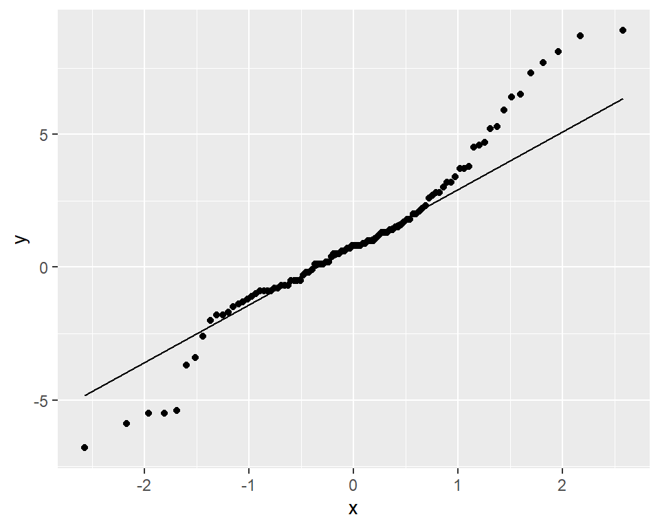

```r
# Check normality
sleep_wide <- sleep |>
  pivot_wider(names_from = condition, values_from = score)

sleep_wide$diff <- sleep_wide$caffeine - sleep_wide$sleep_deprived
# Note: if data isn't ordered by participant diff scores will be incorrect

ggplot(sleep_wide, aes(sample = diff)) +
  stat_qq() +
  stat_qq_line()
```

```r
# Since difference scores are non-normal, running a trimmed paired t-test
library(WRS2)

N <- nrow(sleep_wide)
mu <- 0
G <- 0.2
m <- mean(sleep_wide$diff, tr = G)
var <- winvar(sleep_wide$diff, tr = G)
s <- sqrt(var)
se <- s / ((1 - 2 * G) * sqrt(N))

# Degrees of Freedom
h <- N - 2 * floor(G * N)
df <- h - 1

# Test Statistic
t <- (m - mu) / se

# P-val
p <- pt(t, df = df, lower.tail = FALSE) * 2

# Confidence Interval
alpha <- 0.05
t_crit <- abs(qt(alpha / 2, df = df))

bot_ci <- m - t_crit * se
top_ci <- m + t_crit * se
```

```
## [1] "Test stat = 3.20022"
```

```
## [1] "df = 59"
```

```
## [1] "p = 0.00221163673669784"
```

```
## [1] "95% CI: [0.2835, 1.2298]"
```

$H_0: \mu_D = 0$

# Question 10

*This question was excluded because the way it was worded didn’t clearly reflect what was meant to be asked.*

An instructor designs four unique versions of a midterm exam by randomly selecting questions from a shared question bank. As a result, each version differs slightly in content.

The exam scores are available in **students.csv**.

Do any of the exam versions appear to be significantly harder or easier than the others?

Assume that all classical statistical assumptions are met. You *may* use `lm()`, `aov()`, or `anova()` in your analysis.

```r
# Put data in tidy format
marks <- read_csv("students.csv") |>
  pivot_longer(
    cols = c(everything()),
    names_to = "version",
    values_to = "scores"
  )

# Run a one-way anova
marks$version <- factor(marks$version)
aov_mod <- anova(lm(scores ~ version, data = marks))
aov_mod
```

```
## Analysis of Variance Table
##
## Response: scores
##            Df  Sum Sq Mean Sq F value   Pr(>F)
## version     3   619.9 206.618  3.9132 0.009537 **
## Residuals 208 10982.6  52.801
## ---
## Signif. codes:  0 '***' 0.001 '**' 0.01 '*' 0.05 '.' 0.1 ' ' 1
```

```r
# Calculate effect size
omega_sq <- (aov_mod$`Sum Sq`[1] - aov_mod$Df[1] * aov_mod$`Mean Sq`[2]) /
  (sum(aov_mod$`Sum Sq`) + aov_mod$`Mean Sq`[2])

omega_sq
```

```
## [1] 0.03959175
```

The answer to this question could go either way based on your personal views:

**Option 1:** While the One-Way ANOVA does conclude at least one significant difference is present, the effect size of that difference was quite small (approx. 4% of the variation is accounted for by the exam received). Some difference is always expected and thus the exams are not unfair.

**Option 2:** The exams account for approx. 4% of the variation in the student’s score, which is too high to be fair. A more acceptable threshold would be $x$%.

# Question 11

Using the data in **students.csv**, perform Welch t-tests to evaluate all pairwise comparisons between the exam types.

Apply the Holm-Bonferroni correction to control for multiple comparisons.

Which differences remain statistically significant after the correction?

You may use `t.test()` to conduct your analyses.

```r
marks_wide <- read_csv("students.csv")

#Store P-values
E1vE2 <- t.test(marks_wide$Exam1, marks_wide$Exam2)$p.value
E1vE3 <- t.test(marks_wide$Exam1, marks_wide$Exam3)$p.value
E1vE4 <- t.test(marks_wide$Exam1, marks_wide$Exam4)$p.value
E2vE3 <- t.test(marks_wide$Exam2, marks_wide$Exam3)$p.value
E2vE4 <- t.test(marks_wide$Exam2, marks_wide$Exam4)$p.value
E3vE4 <- t.test(marks_wide$Exam3, marks_wide$Exam4)$p.value

#Store values in data frame
HB <- data.frame("Pair" = c("E1vE2", "E1vE3", "E1vE4",
                            "E2vE3", "E2vE4",
                            "E3vE4"),
                 "pVal" = c(E1vE2, E1vE3, E1vE4,
                            E2vE3, E2vE4,
                            E3vE4))

HB <- arrange(HB, pVal)

HB$Index = nrow(HB):1

HB$alphaPrime = 0.05 / HB$Index

HB$Sig = HB$pVal < HB$alphaPrime

HB
```

```
##    Pair        pVal Index  alphaPrime   Sig
## 1 E1vE3 0.003062825     6 0.008333333  TRUE
## 2 E3vE4 0.007180371     5 0.010000000  TRUE
## 3 E2vE3 0.009773683     4 0.012500000  TRUE
## 4 E1vE4 0.715563543     3 0.016666667 FALSE
## 5 E1vE2 0.773781415     2 0.025000000 FALSE
## 6 E2vE4 0.954782264     1 0.050000000 FALSE
```

The following exams showed a significant difference:

- 1 vs 3
- 3 vs 4
- 2 vs 3

# Question 12

In 1903, statistician Karl Pearson and mathematician Alice Lee collected a large set of physical measurements to examine the statistical relationship between the heights of parents and their adult children (18 years or older). The dataset **pearson_lee_1903.csv** contains the recorded heights (in inches) of parents and their children. *Note: Because the original data were presented as frequency tables, a small amount of random noise has been added to reconstruct individual-level observations.*

- Pearson, K., & Lee, A. (1903). On the Laws of Inheritance in Man: I. Inheritance of Physical Characters. *Biometrika*, *2*(4), 357-462. doi:https://doi.org/10.2307/2331507
- Data: Michael Friendly (2021). HistData: Data Sets from the History of Statistics and Data Visualization. R package version 0.8-7. https://CRAN.R-project.org/package=HistData

Fit the following two ordinary least squares (OLS) regression models:

**Model 1:**

- Predict the child’s height based on the parent’s height.
- Report the model equation and the $R^2$ value.

**Model 2:**

- Extend Model 1 by adding two additional predictors:
  - the sex of the parent
  - the sex of the child
- Code mothers and daughters as 1 and fathers and sons as 0.
- Report the model equation (with the calculated coefficients) and the $R^2$ value.

You are allowed to use `lm()`.

```r
heights <- read_csv("pearson_lee_1903.csv")

#Dummy Coding
heights$Mother <- ifelse(heights$par == "Mother", 1, 0)
heights$Daughter <- ifelse(heights$chl == "Daughter", 1, 0)

#Models
mod1 <- lm(child ~ parent, data = heights)
mod2 <- lm(child ~ parent + Mother + Daughter, data = heights)

mod1sum <- summary(mod1)
mod2sum <- summary(mod2)
```

**Model 1**

$\hat{y} = 40.422 + 0.394 x$

$R^2 = 0.131$

**Model 2**

$\hat{y} = 34.388 + 0.507 x_1 + 2.518 x_2 + (-4.877) x_3$

$R^2 = 0.404$

# Question 13

From the previous question, conduct a test to compare the original single predictor model to the new three predictor model. Which is the preferred model? You are allowed to use `lm()`.

Report the following:

- Test-statistic
- Degrees of freedom
- P-value

```r
# F-test
N <- nrow(heights)
p_modB <- 3
p_diff <- 3 - 1
Rsq_diff <- mod2sum$r.squared - mod1sum$r.squared

F_stat <- ((N - p_modB - 1) / p_diff) *
  (Rsq_diff / (1 - mod2sum$r.squared))

#p-val
p <- pf(F_stat, df1 = p_diff, df2 = N - p_modB - 1, lower.tail = FALSE)
```

```
## [1] "F = 169.9272, df1 = 2, df2 = 742, p = 0"
```

Given that Model 2 explains a significantly greater proportion of the variance compared to Model 1, it is considered the superior model.

# Question 14

Refit the preferred model from the previous question with outliers removed using a robust outlier detection method. List the outliers you removed and report the model equation with it’s $R^2$ value. You are allowed to use `lm()`.

```r
# Note: Outliers should only be removed based on independent/predictor variables
# (i.e., parent height, NOT child height).

# MADN stat
madn <- median(abs(heights$parent - median(heights$parent))) / 0.6745

# Detect outliers
heights$outliers <- (abs(heights$parent - median(heights$parent)) / madn) > 2.24

# Outlier list
heights |> filter(outliers == TRUE)
```

```
## # A tibble: 6 × 7
##   child chl      parent par    Mother Daughter outliers
##   <dbl> <chr>     <dbl> <chr>   <dbl>    <dbl> <lgl>
## 1 61.19 Daughter  52.78 Mother      1        1 TRUE
## 2 61.74 Daughter  52.63 Mother      1        1 TRUE
## 3 61.97 Daughter  52.63 Mother      1        1 TRUE
## 4 62.44 Daughter  53.22 Mother      1        1 TRUE
## 5 62.98 Daughter  52.79 Mother      1        1 TRUE
## 6 63.65 Son       52.3  Mother      1        0 TRUE
```

```r
heights_cln <- heights |> filter(outliers != TRUE)

#Refit model 2
mod2 <- lm(child ~ parent + Mother + Daughter, data = heights_cln)
mod2sum <- summary(mod2)
```

$\hat{y} = 33.5476 + 0.5202 x_1 + 2.5228 x_2 + (-4.9185) x_3$

$R^2 = 0.4041$